# Лабораторная работа №4

Архитектура ОС

Демидович. Н. М.

Российский университет дружбы народов, Москва, Россия

23 февраля 2023

# Докладчик

- Демидович Никита Михайлович
- Студент группы НКАбд-01-22
- Кафедра прикладной информатики и теории вероятностей
- Российский университет дружбы народов
- 1132221550@pfur.ru
- https://github.com/nikdem1

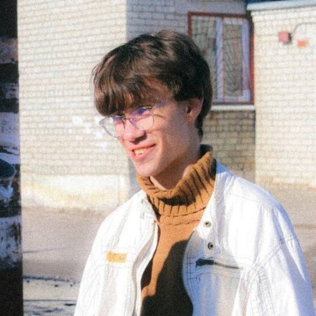

# Цели и задачи

## Цель лабораторной работы

Приобретение практических навыков взаимодействия пользователя с системой посредством командной строки.

# Задачи

1. Определите полное имя вашего домашнего каталога. Далее относительно этого каталога будут выполняться последующие упражнения.
2. Выполните действия, указанные в инструкции по лабораторной работе (работа с каталогами).
3. С помощью команды man определить, какую опцию команды ls нужно использовать для просмотра содержимое не только указанного каталога, но и подкаталогов, входящих в него.
4. С помощью команды man определить набор опций команды ls, позволяющий отсортировать по времени последнего изменения выводимый список содержимого каталога.
5. Используйте команду man для просмотра описания следующих команд: cd, pwd, mkdir, rmdir, rm. Поясните основные опции этих команд.
6. Используя информацию, полученную при помощи команды history, выполните модификацию и исполнение нескольких команд из буфера команд.

# Теоретическое введение

## Команда pwd

Для определения абсолютного пути к текущему каталогу используется команда pwd (print working directory).

## Команда ls

Команда ls используется для просмотра содержимого каталога. Формат команды: `ls [-опции] [путь]`

## Команда mkdir

Команда mkdir используется для создания каталогов. Формат команды: `mkdir имя_каталога1 [имя_каталога2...]`

## Команда rm

Команда rm используется для удаления файлов и/или каталогов. Формат команды: `rm [-опции] [файл]` Если требуется, чтобы выдавался запрос подтверждения на удаление файла, то необходимо использовать опцию i. Чтобы удалить каталог, содержащий файлы, нужно использовать опцию r. Без указания этой опции команда не будет выполняться.

## Команда history

Для вывода на экран списка ранее выполненных команд используется команда history. Выводимые на экран команды в списке нумеруются. К любой команде из выведенного на экран списка можно обратиться по её номеру в списке, воспользовавшись конструкцией `!<номер_команды>`.

## Использование «;»

Если требуется выполнить последовательно несколько команд, записанный в одной строке, то для этого используется символ точка с запятой.

# Выполнение лабораторной работы

Далее описан ход выполнения данной лабораторной работы.

## Определение имени домашнего каталога

На первом этапе выполнения лабораторной работы я воспользовался командами cd и pwd, для того, чтобы определить полное имя своего домашнего каталога.

## Содержимое каталога tmp

Далее я перешёл в каталог tmp и вывел его содержимое. Затем я вывел содержимое каталога tmp, использует опцию “-l”, благодаря чему смог узнать дату и время создания каждого из файлов.

## Содержимое каталога spool

После этого я перешёл в каталог /var/spool и проверил в нём наличие подкаталога под названием cron.

## Содержимое домашнего каталога

Далее мною было выведено содержимое моего домашнего каталога и выяснил, кто является владельцем файлов и подкаталогов.

## Создание и удаление подкаталогов

После чего я создал новый подкаталог с названием “newdir” и подкаталог “morefun” в “newdir”. После этого я создал в домашнем каталоге три подкаталога с названиями “letters”, “memos” и “misk”, удалил подкаталог “morefun” и три ранее созданных подкаталога одной командой.

## Команда man

После этого с помощью команды man я определил, какую опцию команды ls нужно использовать для просмотра содержимое не только указанного каталога, но и подкаталогов, входящих в него (ls -R). Далее, используя команду man, я просмотрел описание следующих команд: cd, pwd, mkdir, rmdir и rm.

## Команда history

И в конце я воспользовался командой history, скопировал оттуда команду для создания архива в формате .tar, модифицировал её и создал архив newdir.tar с ранее созданным подкаталогом.

# Результаты

В результате выполнения данной лабораторной работы я приобрёл практические навыки взаимодействия пользователя с системой посредством командной строки.

# Список источников

Лабораторная работа №4 (Архитектура ОС).